# Applied Statistical Modeling (SoSe 2021) – Homework, Week 4

Marc Blauert

2021-05-06

### Tasks:

McElreath Chapter 4.7, Exercise 4E3, 4M1, and 4H2 (using brms instead of quap)

### 4E3

For the model below, write down the appropriate form of Bayes’ theorem that includes the proper likelihood and priors.

Model:  
$yi ∼ Normal(μ, σ)$  
$μ ∼ Normal(0, 10)$  
$σ ∼ Exponential(1)$

$$p(\mu,\sigma \mid y) = \frac{Normal(yi \mid \mu,\sigma) * Normal(\mu \mid 0,10) * Exponential(\sigma \mid 1)}{\int \int Normal (yi \mid \mu,\sigma)*Normal (\mu \mid 0,10)*Exponential(\sigma \mid 1)*d \mu * d \sigma}$$

### 4M1

For the model below, simulate observed y values from the prior (not the posterior).

Model:  
$yi ∼ Normal(μ, σ)$  
$μ ∼ Normal(0, 10)$  
$σ ∼ Exponential(1)$

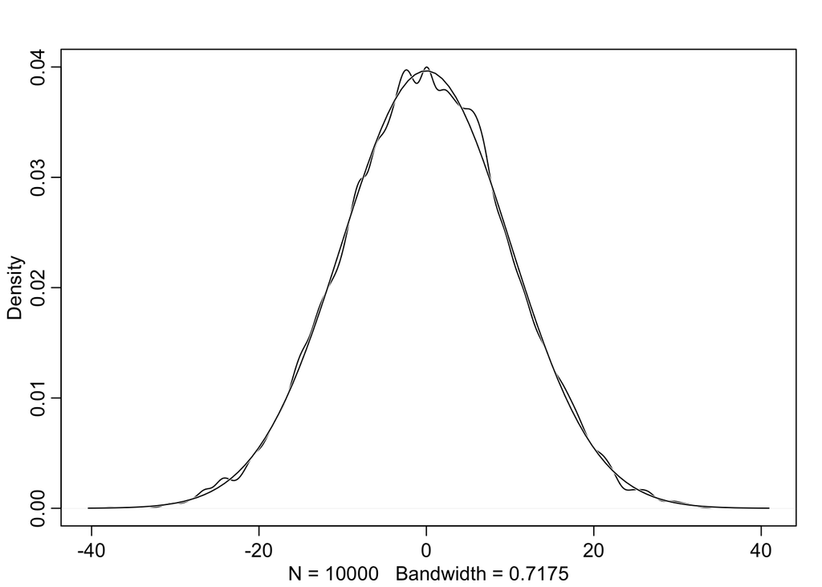

```r
draws <- 10000

sample_mu <- rnorm(draws, 0, 10)
sample_sigma <- rexp(draws, 1)
prior_y <- rnorm(draws, sample_mu, sample_sigma)
dens(prior_y, norm.comp=TRUE)
```

### 4H2 (with brms)

Load the Howell1 data from the Rethinking-package and filter those observations with age <18yrs

```r
data(Howell1)

d <- Howell1 %>%
  filter(age<18) %>%
  mutate(weight_c = weight - mean(weight)) # weight_c --> standardizing the weight variable around 0; 0 as the peak of the normal distribution

# Some summary statistics on the data:

str(d)
```

```
## 'data.frame':    192 obs. of  5 variables:
##  $ height  : num  121.9 105.4 86.4 129.5 109.2 ...
##  $ weight  : num  19.6 13.9 10.5 23.6 16 ...
##  $ age     : num  12 8 6.5 13 7 17 16 11 17 8 ...
##  $ male    : int  1 0 0 1 0 1 0 1 0 1 ...
##  $ weight_c: num  1.2 -4.47 -7.92 5.17 -2.43 ...
```

```r
summary(d$height)
```

```
##    Min. 1st Qu.  Median    Mean 3rd Qu.    Max.
##   53.98   89.13  111.12  108.32  127.72  158.12
```

```r
sd(d$height)
```

```
## [1] 25.74514
```

```r
summary(d$weight)
```

```
##    Min. 1st Qu.  Median    Mean 3rd Qu.    Max.
##   4.252  11.708  16.981  18.414  23.417  44.736
```

### Sub-task (a): Fit a linear regression to these data, using brms. Present and interpret the estimates. For every 10 units of increase in weight, how much taller does the model predict a child gets?

Reminder for myself: The linear model models average height for people <18yrs old in the sample.

```r
fit1 <-
  brm(data = d,
      family = gaussian,
      height ~ 1 + weight_c,
      prior = c(prior(normal(100, 20), class = Intercept),# Prior altered to reflect the data for children
                prior(lognormal(0, 1), class = b),
                prior(uniform(0, 50), class = sigma)),
      iter = 28000, warmup = 27000, chains = 4, cores = 4,
      seed = 4,
      file = "fits/fit1")
```

```r
posterior_summary(fit1)[1:3, ] %>%
  round(digits = 2)
```

```
##             Estimate Est.Error   Q2.5  Q97.5
## b_Intercept   108.30      0.64 107.06 109.61
## b_weight_c      2.71      0.07   2.58   2.85
## sigma           8.55      0.44   7.76   9.45
```

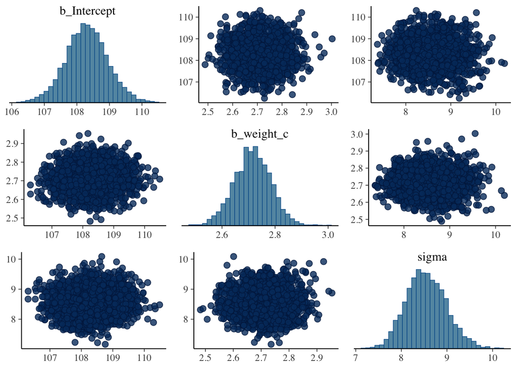

```r
pairs(fit1)
```

```r
prior_summary(fit1)
```

```
##            prior     class     coef group resp dpar nlpar bound       source
##  lognormal(0, 1)         b                                              user
##  lognormal(0, 1)         b weight_c                             (vectorized)
##  normal(100, 20) Intercept                                              user
##   uniform(0, 50)     sigma                                              user
```

Interpretation of the weight_c coefficient: For a 10 unit increase in weight (kg) we observe a 27.2 units increase (cm) in height.

### Sub-task (b): Plot the raw data, with height on the vertical axis and weight on the horizontal axis. Superimpose the MAP regression line and 89% interval for the mean. Also superimpose the 89% interval for predicted heights.

Regression intervals – Plot with regression line and 89% interval for the mean:

```r
# Prepare plotting:

summary(d$weight)
```

```
##    Min. 1st Qu.  Median    Mean 3rd Qu.    Max.
##   4.252  11.708  16.981  18.414  23.417  44.736
```

```r
weight_seq <- tibble(weight = 4:45) %>%
  mutate(weight_c = weight - mean(d$weight))

mu_summary <-
  fitted(fit1,
         newdata = weight_seq,
         probs = c(.055, .945)) %>%
  data.frame() %>%
  bind_cols(weight_seq)

head(mu_summary)
```

```
##   Estimate Est.Error     Q5.5    Q94.5 weight   weight_c
## 1 69.17075 1.1628158 67.37622 71.06514      4 -14.414193
## 2 71.88571 1.1063941 70.16764 73.69407      5 -13.414193
## 3 74.60066 1.0513789 72.96341 76.32965      6 -12.414193
## 4 77.31561 0.9980028 75.75359 78.96184      7 -11.414193
## 5 80.03056 0.9465431 78.55316 81.58693      8 -10.414193
## 6 82.74552 0.8973296 81.34352 84.23049      9  -9.414193
```

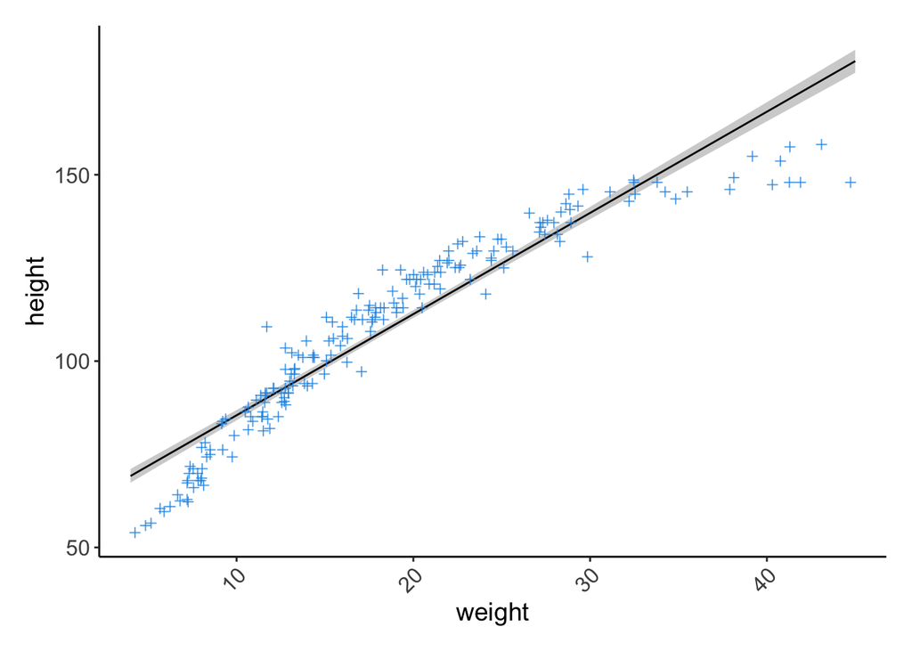

```r
# Plot:

d %>%
  ggplot(aes(x = weight, y = height)) +
  geom_smooth(data = mu_summary,
              aes(y = Estimate, ymin = Q5.5, ymax = Q94.5),
              stat = "identity",
              fill = "grey", color = "black", alpha = 0.7, size = 1/2) +
  geom_point(color = 4, shape = 3, size = 1.5, alpha = 0.8) +
  coord_cartesian(xlim = range(d$weight)) +
  theme_plots()
```

Add prediction intervals – Plot with 89% interval for PREDICTED heights:

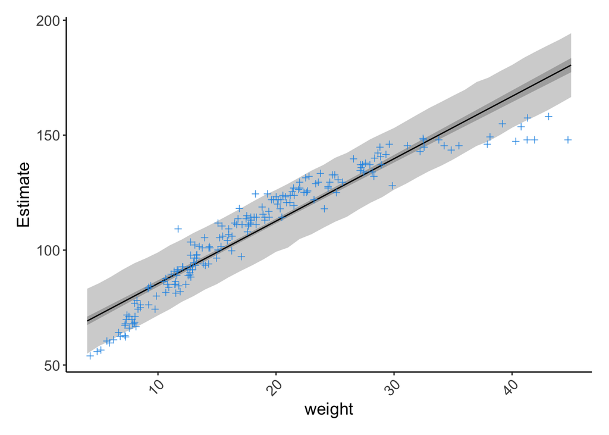

```r
# Goal: Show simulated heights additional to the distributions of plausible average height as in previous plot
# Note: Weight_seq and mu_summary can be re-used here; Yet, we need to use predict() for the predictions

# Prepare plotting:
pred_height <-
  predict(fit1,
          newdata = weight_seq,
          probs = c(.055, .945)) %>%
  data.frame() %>%
  bind_cols(weight_seq)

# Plot:

d %>%
  ggplot(aes(x = weight)) +
  geom_ribbon(data = pred_height,
              aes(ymin = Q5.5, ymax = Q94.5),
              fill = "grey83") +
  geom_smooth(data = mu_summary,
              aes(y = Estimate, ymin = Q5.5, ymax = Q94.5),
              stat = "identity",
              fill = "darkgrey", color = "black", alpha = 0.9, size = 1/2) +
  geom_point(aes(y = height), color = 4, shape = 3, size = 1.5, alpha = 0.8) +
  coord_cartesian(xlim = range(d$weight)) +
  theme_plots()
```

### Sub-task (c): What aspects of the model fit concern you? Describe the kinds of assumptions you would change, if any, to improve the model. You don’t have to write any new code. Just explain what the model appears to be doing a bad job of, and what you hypothesize would be a better model.

- The height of a child in the sample is modeled as a function of its weight. However, no other factor is included. In particular, the inclusion of age would improve the model predictions, since we essentially lump together all developmental stages of children with the simple filter smaller than 18.
- From the two scatter plots shown above, we can see that the linear fit does not really reflect the evolution of height as a function of weight. The relationship is more logarithmic, with height increasing less with higher weight. This may be better modeled by the additional consideration of a log term for weight (not sure about that).